# 2_시간별 유동인구 EDA

```python
%matplotlib inline

import matplotlib.pyplot as plt
import pandas as pd
import seaborn as sns
import numpy as np
from matplotlib import font_manager, rc
```

```python
font_name = font_manager.FontProperties(fname="c:/Windows/Fonts/malgun.ttf").get_name()
rc('font', family=font_name)
```

```python
data = pd.read_csv('./data.csv', header=0, index_col=0, parse_dates=[0])
print(data.shape)
data.head()
```

```
(26976, 31)
```

|  | 수민동 | 복산동 | 명륜동 | 온천1동 | 온천2동 | 온천3동 | 사직1동 | 사직2동 | 사직3동 | 안락1동 | ... | 송정동 | 반여1동 | 반여2동 | 반여3동 | 반여4동 | 반송1동 | 반송2동 | 반송3동 | 재송1동 | 재송2동 |
| --- | --- | --- | --- | --- | --- | --- | --- | --- | --- | --- | --- | --- | --- | --- | --- | --- | --- | --- | --- | --- | --- |
| 2016-02-01 00:00:00 | 27570.0 | 8802.0 | 31963.0 | 39644.0 | 37134.0 | 32460.0 | 10153.0 | 20734.0 | 13913.0 | 21022.0 | ... | 15678.0 | 35442.0 | 12842.0 | 8216.0 | 11239.0 | 10380.0 | 18588.0 | 7593.0 | 35813.0 | 25600.0 |
| 2016-02-01 01:00:00 | 26544.0 | 8036.0 | 33233.0 | 40832.0 | 41477.0 | 34130.0 | 9666.0 | 20827.0 | 12733.0 | 19314.0 | ... | 15727.0 | 31271.0 | 14358.0 | 9295.0 | 10183.0 | 9087.0 | 15992.0 | 6207.0 | 36621.0 | 25305.0 |
| 2016-02-01 02:00:00 | 24471.0 | 6599.0 | 35804.0 | 45040.0 | 39588.0 | 32778.0 | 8880.0 | 18486.0 | 12482.0 | 19740.0 | ... | 13409.0 | 31521.0 | 13458.0 | 9572.0 | 10299.0 | 8135.0 | 16092.0 | 5417.0 | 30981.0 | 24518.0 |
| 2016-02-01 03:00:00 | 27136.0 | 8616.0 | 31643.0 | 46107.0 | 39381.0 | 29297.0 | 9112.0 | 17087.0 | 12224.0 | 18813.0 | ... | 13050.0 | 44031.0 | 14360.0 | 9472.0 | 12804.0 | 10876.0 | 12005.0 | 6142.0 | 29186.0 | 28233.0 |
| 2016-02-01 04:00:00 | 27831.0 | 8038.0 | 26614.0 | 35036.0 | 31410.0 | 27790.0 | 7749.0 | 16105.0 | 12282.0 | 16880.0 | ... | 16381.0 | 61923.0 | 16773.0 | 10368.0 | 18988.0 | 14849.0 | 17021.0 | 8248.0 | 32587.0 | 33475.0 |

5 rows × 31 columns

- ## 주요 통계량

```python
data.describe()
```

|  | 수민동 | 복산동 | 명륜동 | 온천1동 | 온천2동 | 온천3동 | 사직1동 | 사직2동 | 사직3동 | 안락1동 | ... | 송정동 | 반여1동 | 반여2동 | 반여3동 | 반여4동 | 반송1동 | 반송2동 | 반송3동 | 재송1동 | 재송2동 |
| --- | --- | --- | --- | --- | --- | --- | --- | --- | --- | --- | --- | --- | --- | --- | --- | --- | --- | --- | --- | --- | --- |
| count | 26976.000000 | 26976.000000 | 26976.000000 | 26976.000000 | 26976.000000 | 26976.000000 | 26976.000000 | 26976.000000 | 26976.000000 | 26976.000000 | ... | 26976.000000 | 26976.000000 | 26976.000000 | 26976.000000 | 26976.000000 | 26976.000000 | 26976.000000 | 26976.000000 | 26976.000000 | 26976.000000 |
| mean | 31302.748184 | 6445.713820 | 27166.509824 | 35835.018016 | 26399.337782 | 30655.532547 | 11438.523651 | 18516.490362 | 15280.332703 | 16437.253003 | ... | 13817.165221 | 29145.735098 | 6672.747294 | 4912.324177 | 9241.003559 | 11257.080219 | 13994.306902 | 4065.915925 | 37979.931087 | 23266.244254 |
| std | 4341.684423 | 1580.896842 | 5090.334357 | 7965.276513 | 5414.044067 | 5037.532421 | 2698.927884 | 5033.811864 | 3205.502121 | 4701.709186 | ... | 5270.962182 | 6009.556259 | 2624.128067 | 1848.383378 | 2271.418861 | 3080.914348 | 4699.840108 | 2417.327391 | 6859.139286 | 6773.516559 |
| min | 0.000000 | 0.000000 | 0.000000 | 0.000000 | 0.000000 | 0.000000 | 0.000000 | 0.000000 | 0.000000 | 0.000000 | ... | 0.000000 | 0.000000 | 0.000000 | 0.000000 | 0.000000 | 0.000000 | 0.000000 | 0.000000 | 0.000000 | 0.000000 |
| 25% | 28709.500000 | 5282.000000 | 23629.000000 | 29629.750000 | 22925.000000 | 27147.750000 | 9499.000000 | 14869.000000 | 13143.000000 | 13117.000000 | ... | 10609.000000 | 25315.750000 | 4424.750000 | 3261.750000 | 7756.750000 | 8828.750000 | 10122.750000 | 1883.000000 | 33605.000000 | 18675.000000 |
| 50% | 30710.000000 | 6222.000000 | 26772.000000 | 34589.000000 | 25870.000000 | 29963.500000 | 11317.500000 | 18540.500000 | 14660.500000 | 15563.500000 | ... | 12432.500000 | 28204.500000 | 6370.000000 | 4901.000000 | 8862.000000 | 10783.000000 | 14033.000000 | 2696.500000 | 36741.000000 | 20949.500000 |
| 75% | 33292.000000 | 7593.000000 | 29903.000000 | 41744.000000 | 28858.000000 | 33354.500000 | 13083.000000 | 21941.000000 | 17155.250000 | 18908.250000 | ... | 15804.250000 | 31530.250000 | 8394.000000 | 6238.000000 | 10303.000000 | 12925.000000 | 17111.000000 | 6333.000000 | 41884.500000 | 26537.250000 |
| max | 65490.000000 | 17719.000000 | 83236.000000 | 109081.000000 | 91063.000000 | 71390.000000 | 48475.000000 | 63613.000000 | 33212.000000 | 42848.000000 | ... | 60347.000000 | 91921.000000 | 23998.000000 | 14675.000000 | 28237.000000 | 29798.000000 | 55645.000000 | 18933.000000 | 88488.000000 | 78209.000000 |

8 rows × 31 columns

- 데이터의 min 값이 0인 것을 확인
- 유동인구가 0일 수는 없으므로 값을 확인
- 확인결과 0인 sample은 다른 구도 모두 0이며, 측정되지 않은 구간으로 보임
- 측정이 안됬을때는 모두 동일하게 측정이 안되었으므로 상대적 비교를 하는데 전혀 지장이 없으므로 결측값을 처리하지 않음

```python
data[data['수민동']==0].head()
```

|  | 수민동 | 복산동 | 명륜동 | 온천1동 | 온천2동 | 온천3동 | 사직1동 | 사직2동 | 사직3동 | 안락1동 | ... | 송정동 | 반여1동 | 반여2동 | 반여3동 | 반여4동 | 반송1동 | 반송2동 | 반송3동 | 재송1동 | 재송2동 |
| --- | --- | --- | --- | --- | --- | --- | --- | --- | --- | --- | --- | --- | --- | --- | --- | --- | --- | --- | --- | --- | --- |
| 2017-02-14 14:00:00 | 0.0 | 0.0 | 0.0 | 0.0 | 0.0 | 0.0 | 0.0 | 0.0 | 0.0 | 0.0 | ... | 0.0 | 0.0 | 0.0 | 0.0 | 0.0 | 0.0 | 0.0 | 0.0 | 0.0 | 0.0 |
| 2017-02-14 15:00:00 | 0.0 | 0.0 | 0.0 | 0.0 | 0.0 | 0.0 | 0.0 | 0.0 | 0.0 | 0.0 | ... | 0.0 | 0.0 | 0.0 | 0.0 | 0.0 | 0.0 | 0.0 | 0.0 | 0.0 | 0.0 |
| 2017-02-14 16:00:00 | 0.0 | 0.0 | 0.0 | 0.0 | 0.0 | 0.0 | 0.0 | 0.0 | 0.0 | 0.0 | ... | 0.0 | 0.0 | 0.0 | 0.0 | 0.0 | 0.0 | 0.0 | 0.0 | 0.0 | 0.0 |
| 2017-02-14 17:00:00 | 0.0 | 0.0 | 0.0 | 0.0 | 0.0 | 0.0 | 0.0 | 0.0 | 0.0 | 0.0 | ... | 0.0 | 0.0 | 0.0 | 0.0 | 0.0 | 0.0 | 0.0 | 0.0 | 0.0 | 0.0 |
| 2017-02-14 18:00:00 | 0.0 | 0.0 | 0.0 | 0.0 | 0.0 | 0.0 | 0.0 | 0.0 | 0.0 | 0.0 | ... | 0.0 | 0.0 | 0.0 | 0.0 | 0.0 | 0.0 | 0.0 | 0.0 | 0.0 | 0.0 |

5 rows × 31 columns

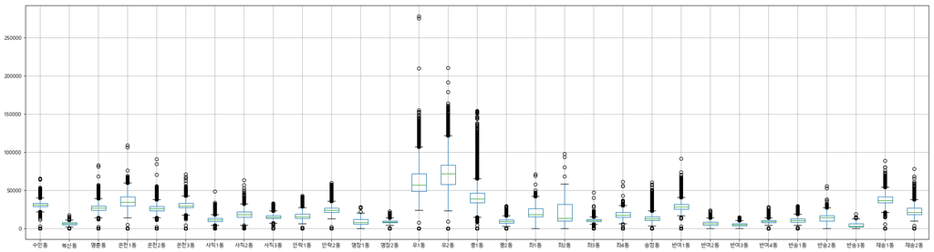

```python
data[data.columns].boxplot(figsize=(30,8))
```

```python
major_gu = ['우1동', '우2동', '중1동', '온천1동', '온천2동', '재송1동' ]
```

```python
data['datetime-year'] = data.index.year
data['datetime-month'] = data.index.month
data['datetime-day'] = data.index.day
data['datetime-hour'] = data.index.hour
data['datetime-dayofweek'] = data.index.day_name()

time_columns = ['datetime-year', 'datetime-month', 'datetime-day', 'datetime-hour', 'datetime-dayofweek']
data[major_gu + time_columns].head()
```

|  | 우1동 | 우2동 | 중1동 | 온천1동 | 온천2동 | 재송1동 | datetime-year | datetime-month | datetime-day | datetime-hour | datetime-dayofweek |
| --- | --- | --- | --- | --- | --- | --- | --- | --- | --- | --- | --- |
| 2016-02-01 00:00:00 | 73987.0 | 41532.0 | 42411.0 | 39644.0 | 37134.0 | 35813.0 | 2016 | 2 | 1 | 0 | Monday |
| 2016-02-01 01:00:00 | 69798.0 | 41122.0 | 45280.0 | 40832.0 | 41477.0 | 36621.0 | 2016 | 2 | 1 | 1 | Monday |
| 2016-02-01 02:00:00 | 75006.0 | 41107.0 | 45227.0 | 45040.0 | 39588.0 | 30981.0 | 2016 | 2 | 1 | 2 | Monday |
| 2016-02-01 03:00:00 | 74389.0 | 34521.0 | 45152.0 | 46107.0 | 39381.0 | 29186.0 | 2016 | 2 | 1 | 3 | Monday |
| 2016-02-01 04:00:00 | 63016.0 | 31262.0 | 42578.0 | 35036.0 | 31410.0 | 32587.0 | 2016 | 2 | 1 | 4 | Monday |

- ## 년도별 주요구 유동인구

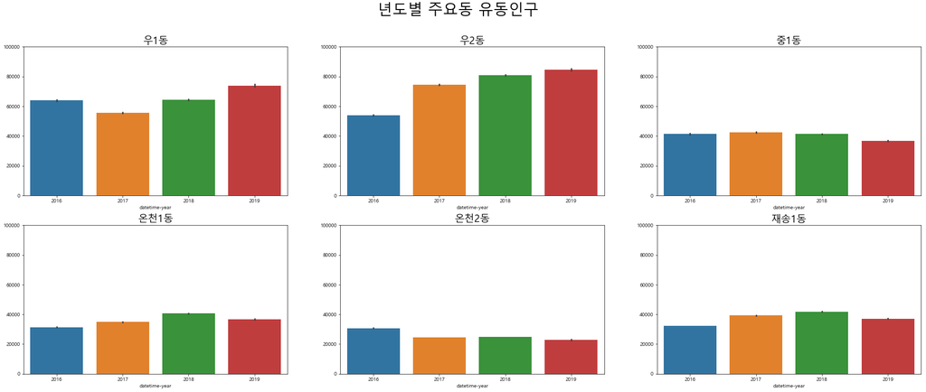

```python
fig, ((ax1, ax2,ax3),(ax4,ax5,ax6)) = plt.subplots(nrows=2, ncols=3)
axes = [ax1, ax2, ax3, ax4, ax5, ax6]
fig.set_size_inches(32,12)
fig.suptitle('년도별 주요동 유동인구', fontsize=30)

for (gu, ax) in zip(major_gu, axes):
    ax.set_ylim(top=100000)
    ax.yaxis.label.set_visible(False)
    ax.set_title(gu, fontdict={'fontsize':20})
    sns.barplot(data=data, x='datetime-year', y=gu, ax = ax)
```

- ## 월별 주요구 유동인구

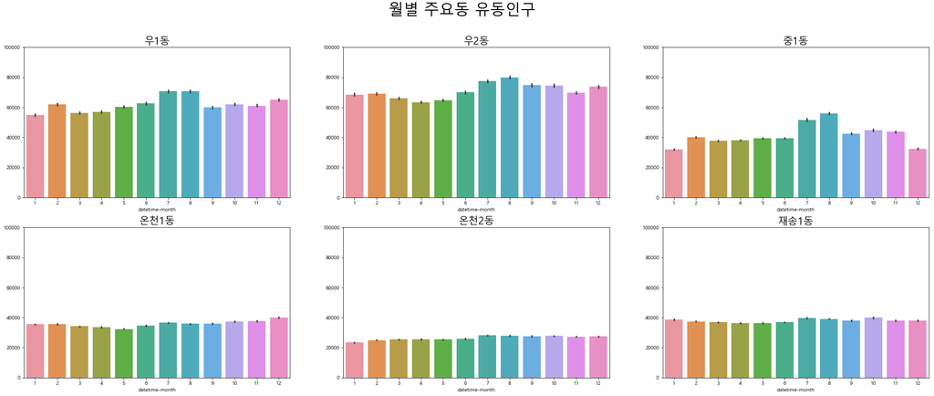

```python
fig, ((ax1, ax2,ax3),(ax4,ax5,ax6)) = plt.subplots(nrows=2, ncols=3)
axes = [ax1, ax2, ax3, ax4, ax5, ax6]
fig.set_size_inches(32,12)
fig.suptitle('월별 주요동 유동인구', fontsize=30)

for (gu, ax) in zip(major_gu, axes):
    ax.set_ylim(top=100000)
    ax.yaxis.label.set_visible(False)
    ax.set_title(gu, fontdict={'fontsize':20})
    sns.barplot(data=data, x='datetime-month', y=gu, ax = ax)
```

- ## 시간별 주요구 유동인구

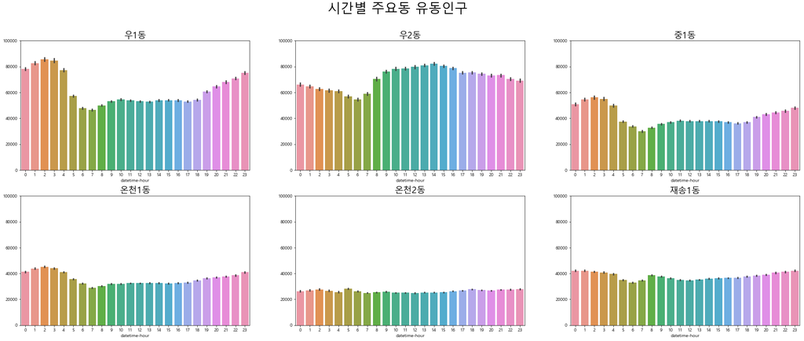

```python
fig, ((ax1, ax2,ax3),(ax4,ax5,ax6)) = plt.subplots(nrows=2, ncols=3)
axes = [ax1, ax2, ax3, ax4, ax5, ax6]
fig.set_size_inches(32,12)
fig.suptitle('시간별 주요동 유동인구', fontsize=30)

for (gu, ax) in zip(major_gu, axes):
    ax.set_ylim(top=100000)
    ax.yaxis.label.set_visible(False)
    ax.set_title(gu, fontdict={'fontsize':20})
    sns.barplot(data=data, x='datetime-hour', y=gu, ax = ax)
```

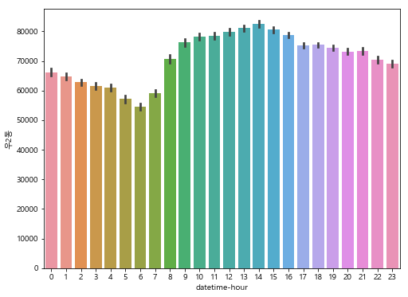

```python
plt.figure(figsize=(8,6))
sns.barplot(data=data, x='datetime-hour', y='우2동')
```

- ## 요일별 주요구 유동인구

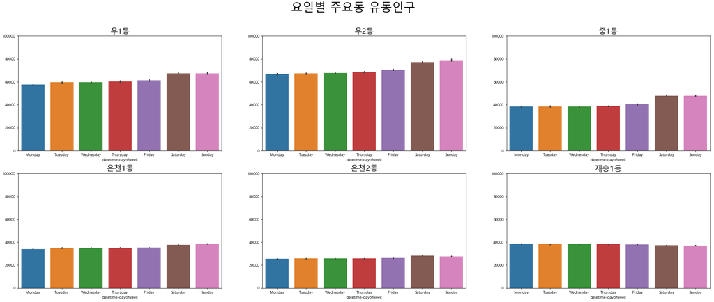

```python
fig, ((ax1, ax2,ax3),(ax4,ax5,ax6)) = plt.subplots(nrows=2, ncols=3)
axes = [ax1, ax2, ax3, ax4, ax5, ax6]
fig.set_size_inches(32,12)
fig.suptitle('요일별 주요동 유동인구', fontsize=30)

for (gu, ax) in zip(major_gu, axes):
    ax.set_ylim(top=100000)
    ax.yaxis.label.set_visible(False)
    ax.set_title(gu, fontdict={'fontsize':20})
    sns.barplot(data=data, x='datetime-dayofweek', y=gu, ax = ax)
```

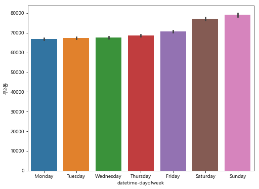

```python
plt.figure(figsize=(8,6))
sns.barplot(data=data, x='datetime-dayofweek', y='우2동')
```

- ## 전체구 상관성 분석

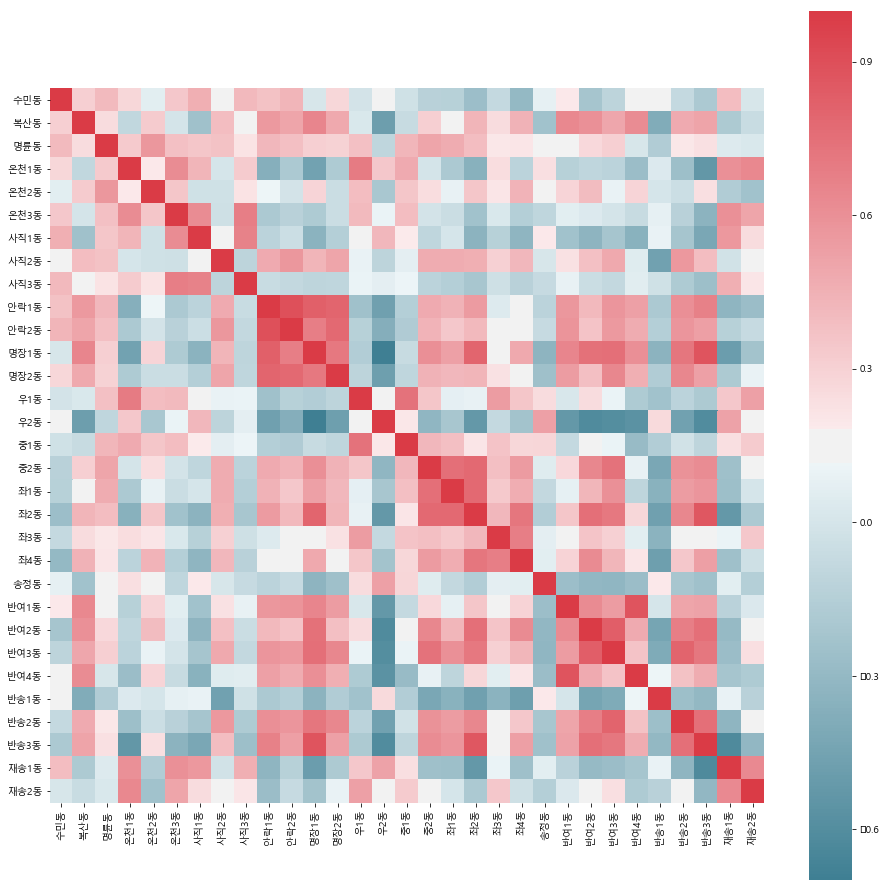

```python
corr_matrix = data.iloc[:,:-5].corr(method='pearson')
plt.figure(figsize=(16,16))
sns.heatmap(corr_matrix, mask=np.zeros_like(corr_matrix, dtype=np.bool), cmap=sns.diverging_palette(220, 10, as_cmap=True), square=True)
```